# Practicing Week 3

Bijan Ranjbar-Sahraei

This is my first markdown R document. In this file I practice the 3rd week of Practical Machine Learning course.

## Predicting with Trees

First import the *iris* data and *ggplot2*

```r
data(iris); library(ggplot2)
```

First check the variables in *iris*:

```r
names(iris)
```

```
## [1] "Sepal.Length" "Sepal.Width"  "Petal.Length" "Petal.Width"
## [5] "Species"
```

The *Species* variable is the output which we want to predict:

```r
table(iris$Species)
```

```
##
##     setosa versicolor  virginica
##         50         50         50
```

Create training and test set

```r
library(caret)
inTrain <- createDataPartition(y=iris$Species,
                               p=0.7,
                               list=FALSE)
training <- iris[inTrain,]
testing <- iris[-inTrain,]
```

```r
dim(training)
```

```
## [1] 105   5
```

```r
dim(testing)
```

```
## [1] 45  5
```

let’s plot the output

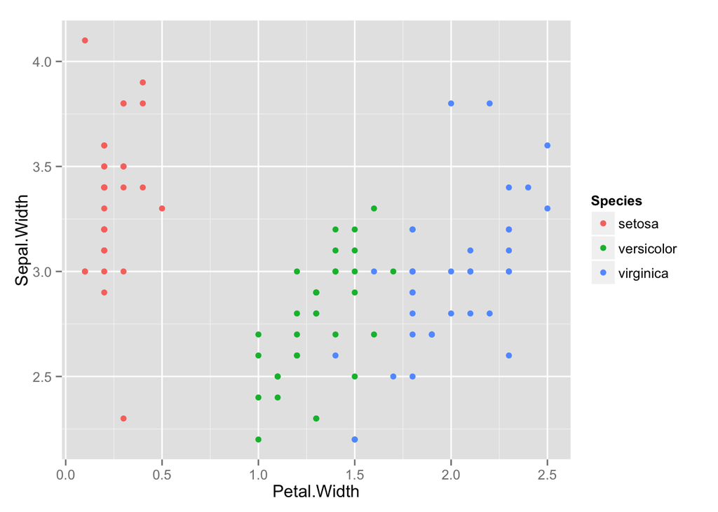

```r
qplot(Petal.Width, Sepal.Width, color=Species, data=training)
```

We see very distinct colors which might be challenging for a linear model but not difficult for trees. Let’s train a tree with *rpart* which is an R package for doing regression and classification trees.

```r
modFit <- train(Species~., method="rpart", data=training)
modFit$finalModel
```

```
## n= 105
##
## node), split, n, loss, yval, (yprob)
##       * denotes terminal node
##
## 1) root 105 70 setosa (0.3333333 0.3333333 0.3333333)
##   2) Petal.Length< 2.45 35  0 setosa (1.0000000 0.0000000 0.0000000) *
##   3) Petal.Length>=2.45 70 35 versicolor (0.0000000 0.5000000 0.5000000)
##     6) Petal.Length< 4.75 32  1 versicolor (0.0000000 0.9687500 0.0312500) *
##     7) Petal.Length>=4.75 38  4 virginica (0.0000000 0.1052632 0.8947368) *
```

It’s also possible to use *party* or *tree* methods, but need more tweeking.

We can also plot the real tree in form of a dendrogram

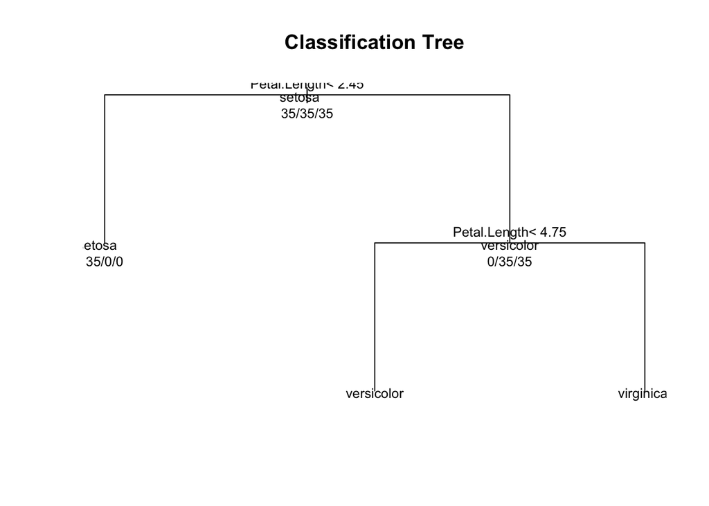

```r
plot(modFit$finalModel, uniform=TRUE, main="Classification Tree")
text(modFit$finalModel, use.n=TRUE, all=TRUE, cex=.8)
```

A prettier version of the dendrogram can be plotted by the *rattle* package for which you might need *install.packages(“RGtk2”)*, *install.packages(“rattle”)* and *install.packages(‘rpart.plot’)*. I had to install *XQuartz.app*, too.

```r
library(rattle)
```

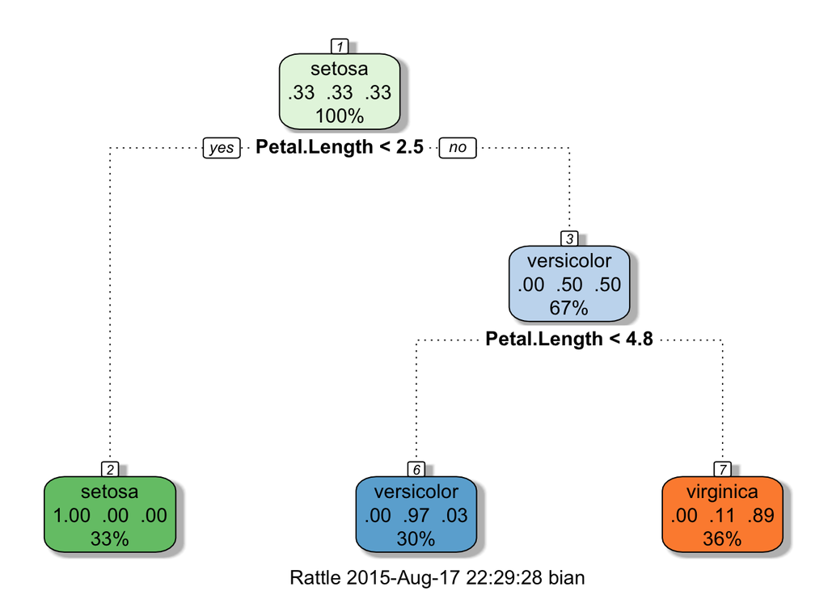

```r
fancyRpartPlot(modFit$finalModel)
```

now we use the decision tree to make predictions.

```r
pred <- predict(modFit, testing)
confusionMatrix(pred,testing$Species)
```

```
## Confusion Matrix and Statistics
##
##             Reference
## Prediction   setosa versicolor virginica
##   setosa         15          0         0
##   versicolor      0         13         0
##   virginica       0          2        15
##
## Overall Statistics
##
##                Accuracy : 0.9556
##                  95% CI : (0.8485, 0.9946)
##     No Information Rate : 0.3333
##     P-Value [Acc > NIR] : < 2.2e-16
##
##                   Kappa : 0.9333
##  Mcnemar's Test P-Value : NA
##
## Statistics by Class:
##
##                      Class: setosa Class: versicolor Class: virginica
## Sensitivity                 1.0000            0.8667           1.0000
## Specificity                 1.0000            1.0000           0.9333
## Pos Pred Value              1.0000            1.0000           0.8824
## Neg Pred Value              1.0000            0.9375           1.0000
## Prevalence                  0.3333            0.3333           0.3333
## Detection Rate              0.3333            0.2889           0.3333
## Detection Prevalence        0.3333            0.2889           0.3778
## Balanced Accuracy           1.0000            0.9333           0.9667
```

## Bagging (Bootstrap Aggregating)

```r
ozone = read.table("~/sandbox/practical-ML-R/weekly-practices/Week 3/ozone.data", header=TRUE)
```

Order the data based on its outcome *ozone*

```r
ozone <- ozone[order(ozone$ozone),]
head(ozone)
```

```
##     ozone radiation temperature wind
## 17      1         8          59  9.7
## 19      4        25          61  9.7
## 14      6        78          57 18.4
## 45      7        48          80 14.3
## 106     7        49          69 10.3
## 7       8        19          61 20.1
```

We want to predict temprature as a function of ozone.

### Bagged Loess (advanced)

```r
ll <- matrix(NA,nrow=10,ncol=155)
for (i in 1:10){
  ss <- sample(1:dim(ozone)[1],replace=T)
  ozone0 <- ozone[ss,]; ozone0 <- ozone0[order(ozone0$ozone),]
  loess0 <- loess(temperature ~ ozone,data=ozone0,span=0.2)  # loess is a smooth curve that you fit through the data, similar to the spline model fit
  ll[i,] <- predict(loess0,newdata=data.frame(ozone=1:155))
}
```

Let’s plot it now.

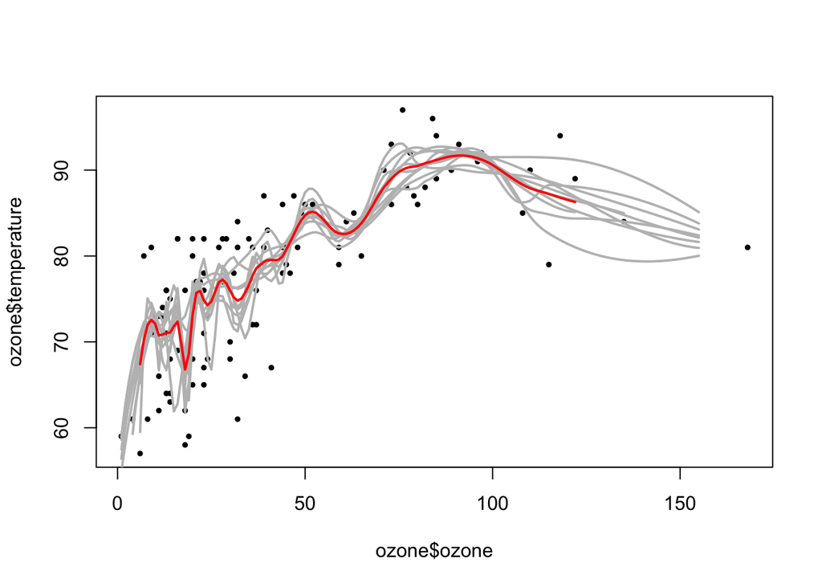

```r
plot(ozone$ozone,ozone$temperature,pch=19,cex=0.5)
for (i in 1:10) {lines(1:155,ll[i,],col="gray",lwd=2)}
lines(1:155,apply(ll,2,mean),col="red",lwd=2)
```

The red line is the **bagged loess** curve which is actually the average of multiple feeded loess cruves which we sampled every time. the bagged loess have lower variability but the same bias as data.

In *Caret* you can use bagged loess. In *train()* function we can use methods *bagEarth*, *treeBag*, or *bagFDA*. We can also use the *bag()* function.

You can build you own bagging in *caret*.

```r
predictors = data.frame(ozone=ozone$ozone)
temprature = ozone$temperature
treebag <- bag(predictors, temprature, B=10,
               bagControl = bagControl(fit=ctreeBag$fit,
                                     predict = ctreeBag$pred,
                                     aggregate = ctreeBag$aggregate))
```

Let’s plot the results

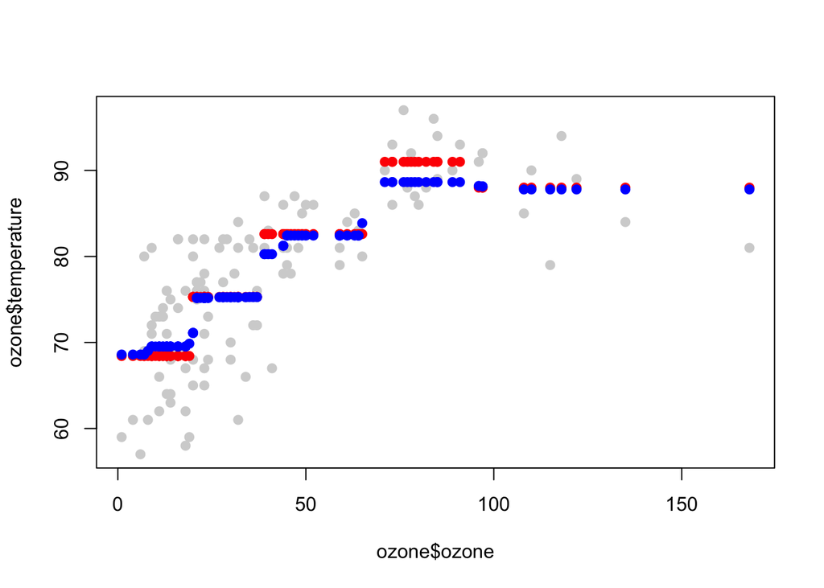

```r
plot(ozone$ozone,ozone$temperature,col="lightgray",pch=19)
points(ozone$ozone,predict(treebag$fits[[1]]$fit, predictors),pch=19,col="red")
points(ozone$ozone,predict(treebag, predictors),pch=19,col="blue")
```

## Random Forests

Let’s look at an example with *iris* database

```r
data(iris); library(ggplot2)
inTrain <- createDataPartition(y=iris$Species,
                             p=0.7, list=FALSE)
training <- iris[inTrain,]
testing <- iris[-inTrain,]
```

Now, let’s feet a model

```r
modFit <- train(Species ~.,data=training,method="rf",
                prox=TRUE)  # prox gives us extra informaiotn that we use in following plot
modFit
```

```
## Random Forest
##
## 105 samples
##   4 predictor
##   3 classes: 'setosa', 'versicolor', 'virginica'
##
## No pre-processing
## Resampling: Bootstrapped (25 reps)
## Summary of sample sizes: 105, 105, 105, 105, 105, 105, ...
## Resampling results across tuning parameters:
##
##   mtry  Accuracy   Kappa      Accuracy SD  Kappa SD
##   2     0.9623657  0.9428262  0.02921899   0.04462382
##   3     0.9642555  0.9457470  0.02914352   0.04434364
##   4     0.9661784  0.9486275  0.02835168   0.04328177
##
## Accuracy was used to select the optimal model using  the largest value.
## The final value used for the model was mtry = 4.
```

we can look at a specific tree

```r
getTree(modFit$finalModel,k=2)
```

```
##   left daughter right daughter split var split point status prediction
## 1             2              3         3        2.45      1          0
## 2             0              0         0        0.00     -1          1
## 3             4              5         4        1.65      1          0
## 4             0              0         0        0.00     -1          2
## 5             0              0         0        0.00     -1          3
```

we can look at class centers

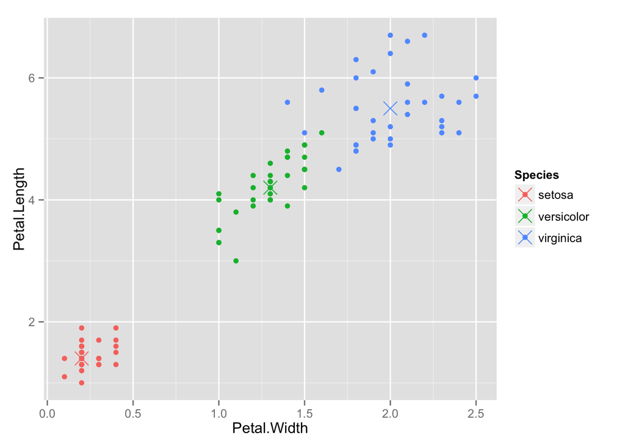

```r
irisP <- classCenter(training[,c(3,4)],training$Species,modFit$finalModel$prox)
irisP <- as.data.frame(irisP); irisP$Species <- rownames(irisP)
p <- qplot(Petal.Width, Petal.Length, col=Species, data=training)
p + geom_point(aes(x=Petal.Width,y=Petal.Length,col=Species),size=5,shape=4,data=irisP)
```

Let’s predict new values

```r
pred <- predict(modFit,testing)
testing$predRight <- (pred==testing$Species)
table(pred,testing$Species)
```

```
##
## pred         setosa versicolor virginica
##   setosa         15          0         0
##   versicolor      0         13         1
##   virginica       0          2        14
```

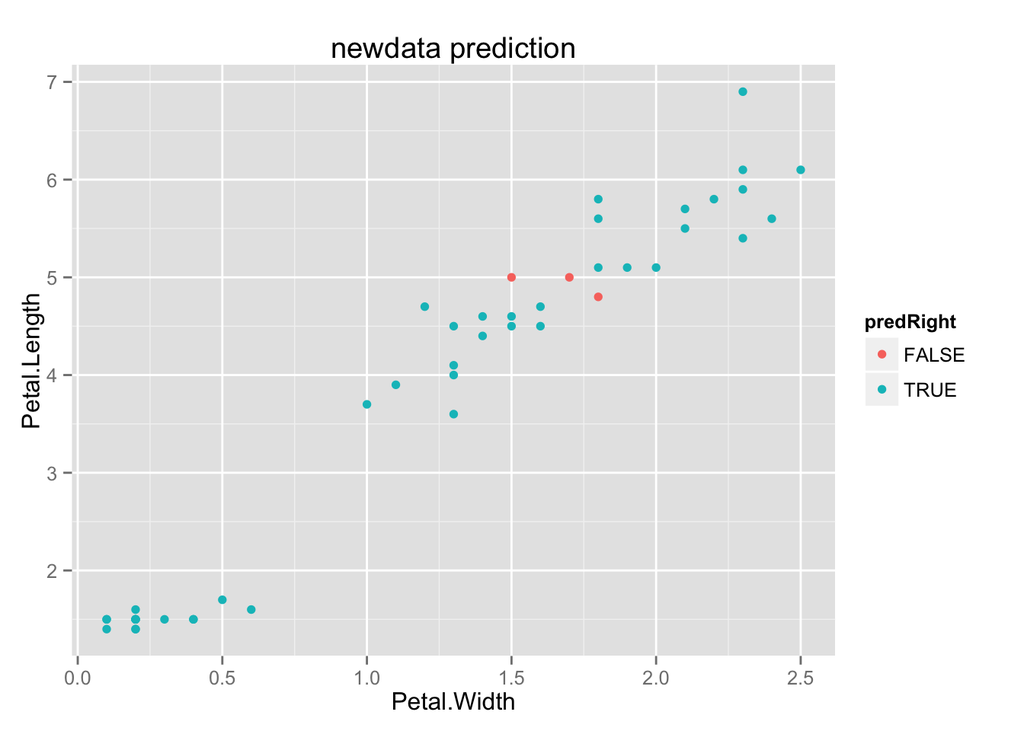

```r
qplot(Petal.Width,Petal.Length,color=predRight,data=testing,main="newdata prediction")
```

## Boosting

```r
library(ISLR); data(Wage); library(ggplot2); library(caret);
Wage <- subset(Wage,select=-c(logwage))
inTrain <- createDataPartition(y=Wage$wage,p=0.7,list=FALSE)
training <- Wage[inTrain,]; testing <- Wage[-inTrain,]

modFit <- train(wage ~ .,
                method="gbm",  # boosting with trees
                data=training,
                verbose=FALSE  # otherwise it will make a lot of outputs
                )
modFit
```

```
## Stochastic Gradient Boosting
##
## 2102 samples
##   10 predictor
##
## No pre-processing
## Resampling: Bootstrapped (25 reps)
## Summary of sample sizes: 2102, 2102, 2102, 2102, 2102, 2102, ...
## Resampling results across tuning parameters:
##
##   interaction.depth  n.trees  RMSE      Rsquared   RMSE SD   Rsquared SD
##   1                   50      35.83192  0.3361653  1.211717  0.02569971
##   1                  100      35.20365  0.3468473  1.203481  0.02502975
##   1                  150      35.10915  0.3483039  1.212504  0.02490199
##   2                   50      35.17639  0.3493230  1.223808  0.02534608
##   2                  100      35.01614  0.3515321  1.216275  0.02506738
##   2                  150      35.09939  0.3486919  1.196353  0.02442008
##   3                   50      35.02683  0.3522902  1.192962  0.02760521
##   3                  100      35.14906  0.3471913  1.172966  0.02364042
##   3                  150      35.36106  0.3404374  1.171253  0.02376170
##
## Tuning parameter 'shrinkage' was held constant at a value of 0.1
##
## Tuning parameter 'n.minobsinnode' was held constant at a value of 10
## RMSE was used to select the optimal model using  the smallest value.
## The final values used for the model were n.trees = 100,
##  interaction.depth = 2, shrinkage = 0.1 and n.minobsinnode = 10.
```

Let’s plot the predicted results

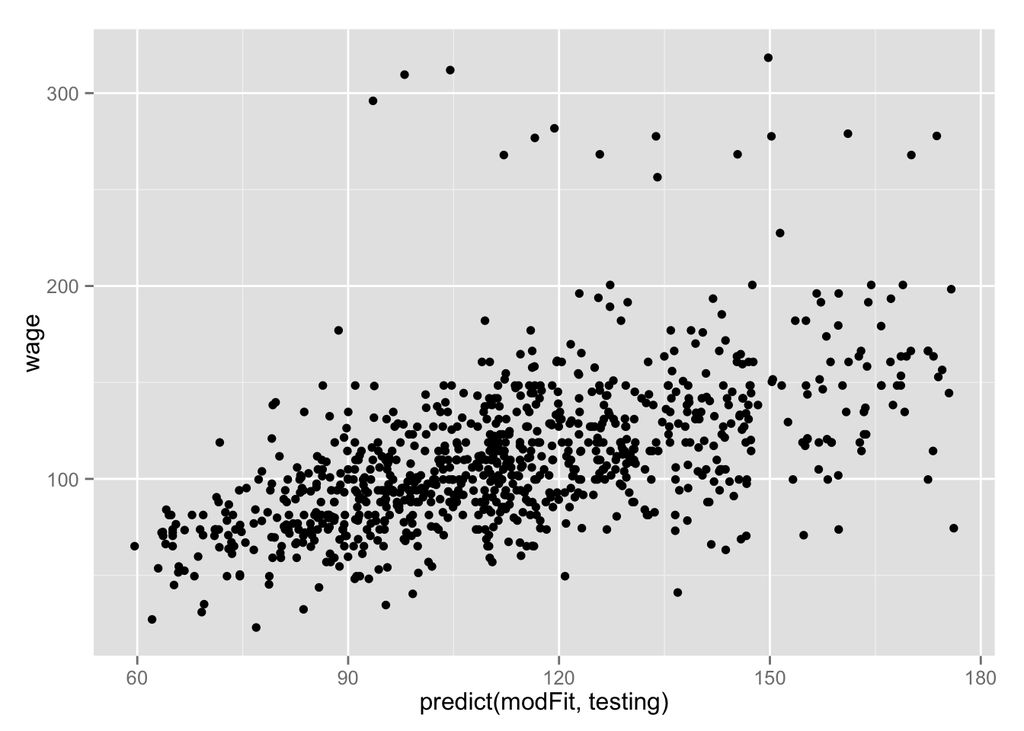

```r
qplot(predict(modFit,testing), wage, data=testing)
```

## Model Based Prediction

```r
data(iris); library(ggplot2)
names(iris)
```

```
## [1] "Sepal.Length" "Sepal.Width"  "Petal.Length" "Petal.Width"
## [5] "Species"
```

```r
table(iris$Species)
```

```
##
##     setosa versicolor  virginica
##         50         50         50
```

```r
inTrain <- createDataPartition(y=iris$Species,p=0.7,list=FALSE)
training <- iris[inTrain,]; testing <- iris[-inTrain,]
```

Build Predictions

```r
modlda <- train(Species~.,
                data=training,
                method="lda")  # Linear Discriminant Analysis
modnb <- train(Species~.,
                data=training,
                method="nb")  # Naive Bayes
plda <- predict(modlda, testing)
pnb <- predict(modnb, testing)
table(plda,pnb)
```

```
##             pnb
## plda         setosa versicolor virginica
##   setosa         15          0         0
##   versicolor      0         14         1
##   virginica       0          1        14
```

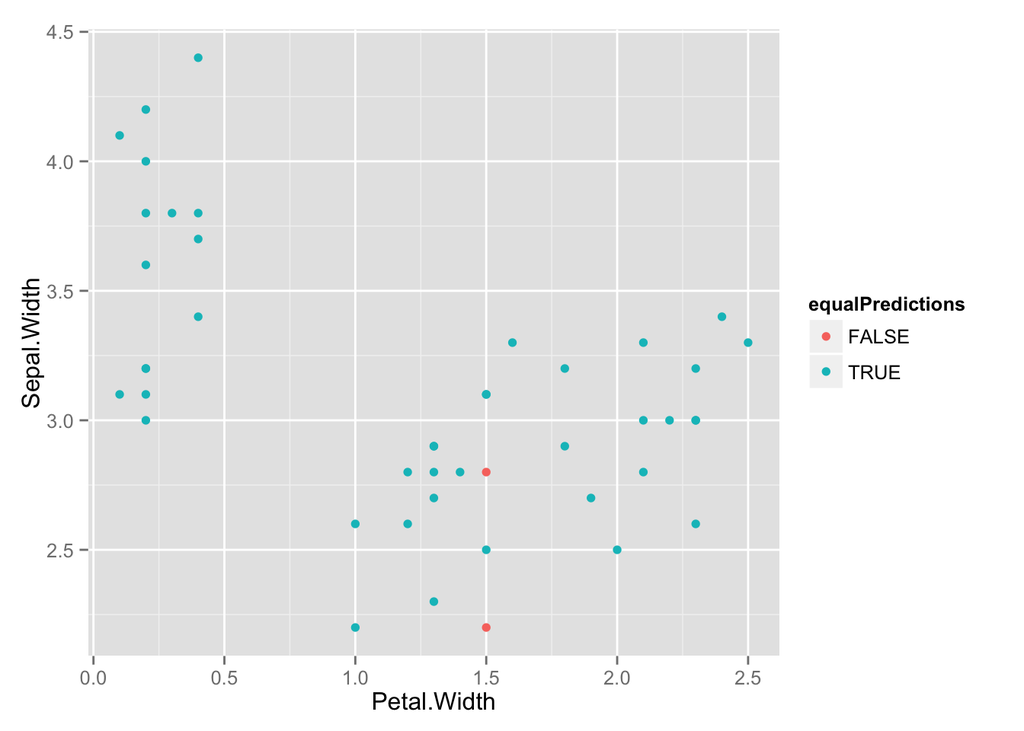

```r
equalPredictions <- (plda==pnb)
qplot(Petal.Width, Sepal.Width,color=equalPredictions,data=testing)
```